# Optimal Treatment Analysis

## Outcome Variable

**Outcome Variable:** whz

## Predictor Variables

**Intervention Variable:** trth2o

**Adjustment Set:**

- arm
- sex
- W_mage
- meducyrs
- feducyrs
- hhwealth_quart
- hfoodsec
- W_mhtcm
- W_mwtkg
- W_mbmi
- W_nrooms
- W_nhh
- W_nchldlt5
- brthmon
- cleanck
- impfloor
- impsan
- safeh20
- delta_meducyrs
- delta_feducyrs
- delta_hhwealth_quart
- delta_hfoodsec
- delta_W_mhtcm
- delta_W_mwtkg
- delta_W_mbmi
- delta_W_nrooms
- delta_W_nhh
- delta_W_nchldlt5
- delta_brthmon
- delta_cleanck
- delta_impfloor
- delta_impsan
- delta_safeh20

## Stratifying Variables

The analysis was stratified on these variable(s):

- agecat
- studyid
- country

## Data Summary

| agecat | studyid | country | trth2o | n_cell | n |
| --- | --- | --- | --- | --- | --- |
| Birth | CMC-V-BCS-2002 | INDIA | 1 | 24 | 24 |
| Birth | CMC-V-BCS-2002 | INDIA | 0 | 0 | 24 |
| Birth | GMS-Nepal | NEPAL | 1 | 1 | 4 |
| Birth | GMS-Nepal | NEPAL | 0 | 3 | 4 |
| Birth | IRC | INDIA | 1 | 105 | 105 |
| Birth | IRC | INDIA | 0 | 0 | 105 |
| Birth | MAL-ED | BANGLADESH | 1 | 110 | 112 |
| Birth | MAL-ED | BANGLADESH | 0 | 2 | 112 |
| Birth | MAL-ED | BRAZIL | 1 | 3 | 20 |
| Birth | MAL-ED | BRAZIL | 0 | 17 | 20 |
| Birth | MAL-ED | INDIA | 1 | 0 | 1 |
| Birth | MAL-ED | INDIA | 0 | 1 | 1 |
| Birth | MAL-ED | NEPAL | 1 | 7 | 9 |
| Birth | MAL-ED | NEPAL | 0 | 2 | 9 |
| Birth | MAL-ED | PERU | 1 | 28 | 36 |
| Birth | MAL-ED | PERU | 0 | 8 | 36 |
| Birth | MAL-ED | SOUTH AFRICA | 1 | 1 | 5 |
| Birth | MAL-ED | SOUTH AFRICA | 0 | 4 | 5 |
| Birth | MAL-ED | TANZANIA, UNITED REPUBLIC OF | 1 | 4 | 21 |
| Birth | MAL-ED | TANZANIA, UNITED REPUBLIC OF | 0 | 17 | 21 |
| Birth | NIH-Crypto | BANGLADESH | 1 | 397 | 707 |
| Birth | NIH-Crypto | BANGLADESH | 0 | 310 | 707 |
| Birth | PROVIDE | BANGLADESH | 1 | 11 | 532 |
| Birth | PROVIDE | BANGLADESH | 0 | 521 | 532 |
| 6 months | CMC-V-BCS-2002 | INDIA | 1 | 120 | 120 |
| 6 months | CMC-V-BCS-2002 | INDIA | 0 | 0 | 120 |
| 6 months | GMS-Nepal | NEPAL | 1 | 1 | 4 |
| 6 months | GMS-Nepal | NEPAL | 0 | 3 | 4 |
| 6 months | IRC | INDIA | 1 | 121 | 121 |
| 6 months | IRC | INDIA | 0 | 0 | 121 |
| 6 months | MAL-ED | BANGLADESH | 1 | 132 | 134 |
| 6 months | MAL-ED | BANGLADESH | 0 | 2 | 134 |
| 6 months | MAL-ED | BRAZIL | 1 | 13 | 103 |
| 6 months | MAL-ED | BRAZIL | 0 | 90 | 103 |
| 6 months | MAL-ED | INDIA | 1 | 4 | 9 |
| 6 months | MAL-ED | INDIA | 0 | 5 | 9 |
| 6 months | MAL-ED | NEPAL | 1 | 69 | 83 |
| 6 months | MAL-ED | NEPAL | 0 | 14 | 83 |
| 6 months | MAL-ED | PERU | 1 | 39 | 49 |
| 6 months | MAL-ED | PERU | 0 | 10 | 49 |
| 6 months | MAL-ED | SOUTH AFRICA | 1 | 2 | 12 |
| 6 months | MAL-ED | SOUTH AFRICA | 0 | 10 | 12 |
| 6 months | MAL-ED | TANZANIA, UNITED REPUBLIC OF | 1 | 6 | 42 |
| 6 months | MAL-ED | TANZANIA, UNITED REPUBLIC OF | 0 | 36 | 42 |
| 6 months | NIH-Crypto | BANGLADESH | 1 | 396 | 715 |
| 6 months | NIH-Crypto | BANGLADESH | 0 | 319 | 715 |
| 6 months | PROVIDE | BANGLADESH | 1 | 14 | 603 |
| 6 months | PROVIDE | BANGLADESH | 0 | 589 | 603 |
| 24 months | CMC-V-BCS-2002 | INDIA | 1 | 119 | 119 |
| 24 months | CMC-V-BCS-2002 | INDIA | 0 | 0 | 119 |
| 24 months | GMS-Nepal | NEPAL | 1 | 1 | 4 |
| 24 months | GMS-Nepal | NEPAL | 0 | 3 | 4 |
| 24 months | IRC | INDIA | 1 | 121 | 121 |
| 24 months | IRC | INDIA | 0 | 0 | 121 |
| 24 months | MAL-ED | BANGLADESH | 1 | 133 | 135 |
| 24 months | MAL-ED | BANGLADESH | 0 | 2 | 135 |
| 24 months | MAL-ED | BRAZIL | 1 | 13 | 103 |
| 24 months | MAL-ED | BRAZIL | 0 | 90 | 103 |
| 24 months | MAL-ED | INDIA | 1 | 4 | 9 |
| 24 months | MAL-ED | INDIA | 0 | 5 | 9 |
| 24 months | MAL-ED | NEPAL | 1 | 69 | 83 |
| 24 months | MAL-ED | NEPAL | 0 | 14 | 83 |
| 24 months | MAL-ED | PERU | 1 | 39 | 49 |
| 24 months | MAL-ED | PERU | 0 | 10 | 49 |
| 24 months | MAL-ED | SOUTH AFRICA | 1 | 2 | 11 |
| 24 months | MAL-ED | SOUTH AFRICA | 0 | 9 | 11 |
| 24 months | MAL-ED | TANZANIA, UNITED REPUBLIC OF | 1 | 6 | 43 |
| 24 months | MAL-ED | TANZANIA, UNITED REPUBLIC OF | 0 | 37 | 43 |
| 24 months | NIH-Crypto | BANGLADESH | 1 | 242 | 514 |
| 24 months | NIH-Crypto | BANGLADESH | 0 | 272 | 514 |
| 24 months | PROVIDE | BANGLADESH | 1 | 14 | 579 |
| 24 months | PROVIDE | BANGLADESH | 0 | 565 | 579 |

The following strata were considered:

- agecat: 24 months, studyid: CMC-V-BCS-2002, country: INDIA
- agecat: 24 months, studyid: GMS-Nepal, country: NEPAL
- agecat: 24 months, studyid: IRC, country: INDIA
- agecat: 24 months, studyid: MAL-ED, country: BANGLADESH
- agecat: 24 months, studyid: MAL-ED, country: BRAZIL
- agecat: 24 months, studyid: MAL-ED, country: INDIA
- agecat: 24 months, studyid: MAL-ED, country: NEPAL
- agecat: 24 months, studyid: MAL-ED, country: PERU
- agecat: 24 months, studyid: MAL-ED, country: SOUTH AFRICA
- agecat: 24 months, studyid: MAL-ED, country: TANZANIA, UNITED REPUBLIC OF
- agecat: 24 months, studyid: NIH-Crypto, country: BANGLADESH
- agecat: 24 months, studyid: PROVIDE, country: BANGLADESH
- agecat: 6 months, studyid: CMC-V-BCS-2002, country: INDIA
- agecat: 6 months, studyid: GMS-Nepal, country: NEPAL
- agecat: 6 months, studyid: IRC, country: INDIA
- agecat: 6 months, studyid: MAL-ED, country: BANGLADESH
- agecat: 6 months, studyid: MAL-ED, country: BRAZIL
- agecat: 6 months, studyid: MAL-ED, country: INDIA
- agecat: 6 months, studyid: MAL-ED, country: NEPAL
- agecat: 6 months, studyid: MAL-ED, country: PERU
- agecat: 6 months, studyid: MAL-ED, country: SOUTH AFRICA
- agecat: 6 months, studyid: MAL-ED, country: TANZANIA, UNITED REPUBLIC OF
- agecat: 6 months, studyid: NIH-Crypto, country: BANGLADESH
- agecat: 6 months, studyid: PROVIDE, country: BANGLADESH
- agecat: Birth, studyid: CMC-V-BCS-2002, country: INDIA
- agecat: Birth, studyid: GMS-Nepal, country: NEPAL
- agecat: Birth, studyid: IRC, country: INDIA
- agecat: Birth, studyid: MAL-ED, country: BANGLADESH
- agecat: Birth, studyid: MAL-ED, country: BRAZIL
- agecat: Birth, studyid: MAL-ED, country: INDIA
- agecat: Birth, studyid: MAL-ED, country: NEPAL
- agecat: Birth, studyid: MAL-ED, country: PERU
- agecat: Birth, studyid: MAL-ED, country: SOUTH AFRICA
- agecat: Birth, studyid: MAL-ED, country: TANZANIA, UNITED REPUBLIC OF
- agecat: Birth, studyid: NIH-Crypto, country: BANGLADESH
- agecat: Birth, studyid: PROVIDE, country: BANGLADESH

### Dropped Strata

Some strata were dropped due to rare outcomes:

- agecat: Birth, studyid: CMC-V-BCS-2002, country: INDIA
- agecat: Birth, studyid: GMS-Nepal, country: NEPAL
- agecat: Birth, studyid: IRC, country: INDIA
- agecat: Birth, studyid: MAL-ED, country: BANGLADESH
- agecat: Birth, studyid: MAL-ED, country: BRAZIL
- agecat: Birth, studyid: MAL-ED, country: INDIA
- agecat: Birth, studyid: MAL-ED, country: NEPAL
- agecat: Birth, studyid: MAL-ED, country: SOUTH AFRICA
- agecat: Birth, studyid: MAL-ED, country: TANZANIA, UNITED REPUBLIC OF
- agecat: 6 months, studyid: CMC-V-BCS-2002, country: INDIA
- agecat: 6 months, studyid: GMS-Nepal, country: NEPAL
- agecat: 6 months, studyid: IRC, country: INDIA
- agecat: 6 months, studyid: MAL-ED, country: BANGLADESH
- agecat: 6 months, studyid: MAL-ED, country: INDIA
- agecat: 6 months, studyid: MAL-ED, country: SOUTH AFRICA
- agecat: 24 months, studyid: CMC-V-BCS-2002, country: INDIA
- agecat: 24 months, studyid: GMS-Nepal, country: NEPAL
- agecat: 24 months, studyid: IRC, country: INDIA
- agecat: 24 months, studyid: MAL-ED, country: BANGLADESH
- agecat: 24 months, studyid: MAL-ED, country: INDIA
- agecat: 24 months, studyid: MAL-ED, country: SOUTH AFRICA

## Methods Detail

We’re interested in the causal parameters $E[Y_a]$ for all values of $a \in \mathcal{A}$. These parameters represent the mean outcome if, possibly contrary to fact, we intervened to set all units to have $A=a$. Under the randomization and positivity assumptions, these are identified by the statistical parameters $\psi_a=E_W[E_{Y|A,W}(Y|A=a,W)]$. In addition, we’re interested in the mean of $Y$, $E[Y]$ under no intervention (the observed mean). We will estimate these parameters by using SuperLearner to fit the relevant likelihood factors – $E_{Y|A,W}(Y|A=a,W)$ and $p(A=a|W)$, and then updating our likelihood fit using a joint TMLE.

For unadjusted analyses ($W=\{\}$), initial likelihoods were estimated using Lrnr_glm to estimate the simple $E(Y|A)$ and Lrnr_mean to estimate $p(A)$. For adjusted analyses, a small library containing Lrnr_glmnet, Lrnr_xgboost, and Lrnr_mean was used.

# Results Detail

## Results Plots

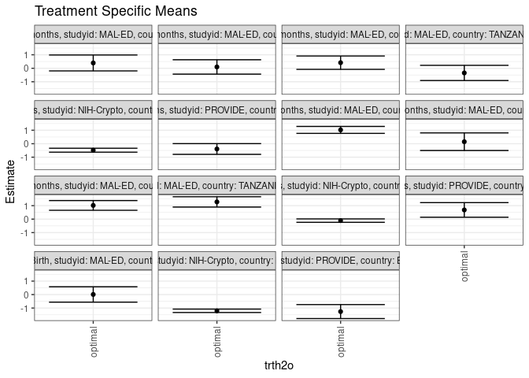

## Results Table

### Parameter: TSM

| agecat | studyid | country | intervention_level | baseline_level | estimate | ci_lower | ci_upper |
| --- | --- | --- | --- | --- | --- | --- | --- |
| Birth | MAL-ED | PERU | optimal | observed | 0.0085673 | -0.5627029 | 0.5798375 |
| Birth | NIH-Crypto | BANGLADESH | optimal | observed | -1.2039674 | -1.3311175 | -1.0768174 |
| Birth | PROVIDE | BANGLADESH | optimal | observed | -1.2610101 | -1.7796262 | -0.7423941 |
| 6 months | MAL-ED | BRAZIL | optimal | observed | 1.0246408 | 0.7669117 | 1.2823700 |
| 6 months | MAL-ED | NEPAL | optimal | observed | 0.1474478 | -0.5058711 | 0.8007668 |
| 6 months | MAL-ED | PERU | optimal | observed | 1.0182898 | 0.6564471 | 1.3801325 |
| 6 months | MAL-ED | TANZANIA, UNITED REPUBLIC OF | optimal | observed | 1.2791224 | 0.8959845 | 1.6622604 |
| 6 months | NIH-Crypto | BANGLADESH | optimal | observed | -0.1091259 | -0.2360936 | 0.0178419 |
| 6 months | PROVIDE | BANGLADESH | optimal | observed | 0.6832609 | 0.1404784 | 1.2260434 |
| 24 months | MAL-ED | BRAZIL | optimal | observed | 0.3942874 | -0.1964006 | 0.9849755 |
| 24 months | MAL-ED | NEPAL | optimal | observed | 0.0990619 | -0.4347132 | 0.6328370 |
| 24 months | MAL-ED | PERU | optimal | observed | 0.4146118 | -0.0822370 | 0.9114606 |
| 24 months | MAL-ED | TANZANIA, UNITED REPUBLIC OF | optimal | observed | -0.3454052 | -0.9086469 | 0.2178364 |
| 24 months | NIH-Crypto | BANGLADESH | optimal | observed | -0.4820269 | -0.6290527 | -0.3350011 |
| 24 months | PROVIDE | BANGLADESH | optimal | observed | -0.3912527 | -0.7900381 | 0.0075327 |

### Parameter: E(Y)

| agecat | studyid | country | intervention_level | baseline_level | estimate | ci_lower | ci_upper |
| --- | --- | --- | --- | --- | --- | --- | --- |
| Birth | MAL-ED | PERU | observed | observed | -0.1791667 | -0.4729428 | 0.1146094 |
| Birth | NIH-Crypto | BANGLADESH | observed | observed | -1.2441513 | -1.3281130 | -1.1601897 |
| Birth | PROVIDE | BANGLADESH | observed | observed | -1.2984586 | -1.3752758 | -1.2216415 |
| 6 months | MAL-ED | BRAZIL | observed | observed | 0.9731715 | 0.7347562 | 1.2115869 |
| 6 months | MAL-ED | NEPAL | observed | observed | 0.1447189 | -0.1029021 | 0.3923399 |
| 6 months | MAL-ED | PERU | observed | observed | 0.9109184 | 0.5934529 | 1.2283839 |
| 6 months | MAL-ED | TANZANIA, UNITED REPUBLIC OF | observed | observed | 0.7418651 | 0.4248303 | 1.0588998 |
| 6 months | NIH-Crypto | BANGLADESH | observed | observed | 0.0297622 | -0.0491685 | 0.1086930 |
| 6 months | PROVIDE | BANGLADESH | observed | observed | -0.1990907 | -0.2817968 | -0.1163845 |
| 24 months | MAL-ED | BRAZIL | observed | observed | 0.5203560 | 0.2632846 | 0.7774274 |
| 24 months | MAL-ED | NEPAL | observed | observed | -0.2262651 | -0.4277663 | -0.0247638 |
| 24 months | MAL-ED | PERU | observed | observed | 0.1148299 | -0.1831101 | 0.4127700 |
| 24 months | MAL-ED | TANZANIA, UNITED REPUBLIC OF | observed | observed | 0.1037209 | -0.1942394 | 0.4016813 |
| 24 months | NIH-Crypto | BANGLADESH | observed | observed | -0.6103502 | -0.7050157 | -0.5156847 |
| 24 months | PROVIDE | BANGLADESH | observed | observed | -0.8928670 | -0.9755153 | -0.8102187 |

### Parameter: PAR

| agecat | studyid | country | intervention_level | baseline_level | estimate | ci_lower | ci_upper |
| --- | --- | --- | --- | --- | --- | --- | --- |
| Birth | MAL-ED | PERU | optimal | observed | -0.1877340 | -0.7511944 | 0.3757264 |
| Birth | NIH-Crypto | BANGLADESH | optimal | observed | -0.0401839 | -0.1376770 | 0.0573092 |
| Birth | PROVIDE | BANGLADESH | optimal | observed | -0.0374485 | -0.5434150 | 0.4685180 |
| 6 months | MAL-ED | BRAZIL | optimal | observed | -0.0514693 | -0.1382962 | 0.0353575 |
| 6 months | MAL-ED | NEPAL | optimal | observed | -0.0027290 | -0.6006879 | 0.5952300 |
| 6 months | MAL-ED | PERU | optimal | observed | -0.1073715 | -0.2593630 | 0.0446201 |
| 6 months | MAL-ED | TANZANIA, UNITED REPUBLIC OF | optimal | observed | -0.5372574 | -1.0085398 | -0.0659750 |
| 6 months | NIH-Crypto | BANGLADESH | optimal | observed | 0.1388881 | 0.0361602 | 0.2416160 |
| 6 months | PROVIDE | BANGLADESH | optimal | observed | -0.8823515 | -1.4187828 | -0.3459203 |
| 24 months | MAL-ED | BRAZIL | optimal | observed | 0.1260686 | -0.4065312 | 0.6586683 |
| 24 months | MAL-ED | NEPAL | optimal | observed | -0.3253269 | -0.8051026 | 0.1544487 |
| 24 months | MAL-ED | PERU | optimal | observed | -0.2997818 | -0.6422818 | 0.0427181 |
| 24 months | MAL-ED | TANZANIA, UNITED REPUBLIC OF | optimal | observed | 0.4491261 | -0.1059622 | 1.0042145 |
| 24 months | NIH-Crypto | BANGLADESH | optimal | observed | -0.1283233 | -0.2387528 | -0.0178938 |
| 24 months | PROVIDE | BANGLADESH | optimal | observed | -0.5016143 | -0.8991785 | -0.1040501 |